# The Project

1. This is a project with minimal scaffolding. Expect to use the the discussion forums to gain insights! It’s not cheating to ask others for opinions or perspectives!
2. Be inquisitive, try out new things.
3. Use the previous modules for insights into how to complete the functions! You'll have to combine Pillow, OpenCV, and Pytesseract
4. There are hints provided in Coursera, feel free to explore the hints if needed. Each hint provide progressively more details on how to solve the issue. This project is intended to be comprehensive and difficult if you do it without the hints.

### The Assignment

Take a ZIP file) of images and process them, using a [library built into python](https://docs.python.org/3/library/zipfile.html) that you need to learn how to use. A ZIP file takes several different files and compresses them, thus saving space, into one single file. The files in the ZIP file we provide are newspaper images (like you saw in week 3). Your task is to write python code which allows one to search through the images looking for the occurrences of keywords and faces. E.g. if you search for "pizza" it will return a contact sheet of all of the faces which were located on the newspaper page which mentions "pizza". This will test your ability to learn a new ([library](https://docs.python.org/3/library/zipfile.html)), your ability to use OpenCV to detect faces, your ability to use tesseract to do optical character recognition, and your ability to use PIL to composite images together into contact sheets.

Each page of the newspapers is saved as a single PNG image in a file called images.zip. These newspapers are in english, and contain a variety of stories, advertisements and images. Note: This file is fairly large (~200 MB) and may take some time to work with, I would encourage you to use small_img.zip for testing.

Here's an example of the output expected. Using the small_img.zip file, if I search for the string "Christopher" I should see the following image:

[figure not shown]

If I were to use the images.zip file and search for "Mark" I should see the following image (note that there are times when there are no faces on a page, but a word is found!):

[figure not shown]

Note: That big file can take some time to process - for me it took nearly ten minutes! Use the small one for testing.

```python
import zipfile

from PIL import Image
import pytesseract
import cv2 as cv
import numpy as np

# loading the face detection classifier
face_cascade = cv.CascadeClassifier('readonly/haarcascade_frontalface_default.xml')

# the rest is up to you!

import zipfile
import io

def binarize(image_to_transform, threshold):
    # now, lets convert that image to a single greyscale image using convert()
    output_image=image_to_transform.convert("L")
    # the threshold value is usually provided as a number between 0 and 255, which
    # is the number of bits in a byte.
    # the algorithm for the binarization is pretty simple, go through every pixel in the
    # image and, if it's greater than the threshold, turn it all the way up (255), and
    # if it's lower than the threshold, turn it all the way down (0).
    # so lets write this in code. First, we need to iterate over all of the pixels in the
    # image we want to work with
    for x in range(output_image.width):
        for y in range(output_image.height):
            # for the given pixel at w,h, lets check its value against the threshold
            if output_image.getpixel((x,y))< threshold: #note that the first parameter is actually a tuple object
                # lets set this to zero
                output_image.putpixel( (x,y), 0 )
            else:
                # otherwise lets set this to 255
                output_image.putpixel( (x,y), 255 )
    #now we just return the new image
    return output_image

arc = zipfile.ZipFile('readonly/small_img.zip', 'r') #create handle to zipfile
names = arc.namelist()
img_objects = []
for name in names:
    #extract file from zip in memory
    get_img = arc.read(name)
    print(name)
    # then as a file type handle

    fh = io.BytesIO(get_img)
    img = Image.open(fh)
    text = pytesseract.image_to_string(binarize(img, 128))
    img_objects.append({'name': name, 'imag':img, 'text':text})
print(img_objects)
    #display(img)
```

[output not shown]

```python
from numpy import asarray
from PIL import ImageDraw
#i=1
faces_crop = []
img_crop = []
for di in img_objects:
    if "Christopher" in di['text']:
        data = asarray(di['imag'])
        #img2 = cv.imread("di['imag']")
        gray = cv.cvtColor(data, cv.COLOR_BGR2GRAY)
        #pil_img=Image.fromarray(gray,mode="L")
        faces = face_cascade.detectMultiScale(gray,1.40)
        #drawing=ImageDraw.Draw(di['imag'])
# And iterate through the faces sequence, tuple unpacking as we go
        for x,y,w,h in faces:
# And remember this is width and height so we have to add those appropriately.
            img_crop.append(di['imag'].crop((x,y,x+w,y+h)))
        faces_crop.append({ 'name':di['name'], 'images2': img_crop})
        img_crop = []
        #print(faces)
        #else:
            #faces_crop.append({ 'name':di['name'], 'images2': img_crop})
#empty = []

        #print(i)
        #i=i+1
```

```
Results found in file a-0.png:
```

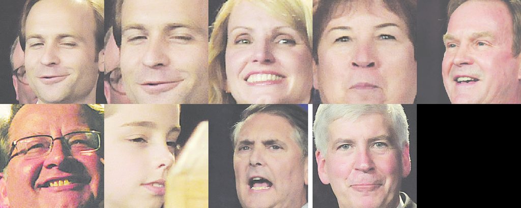

```
Results found in file a-3.png:
```

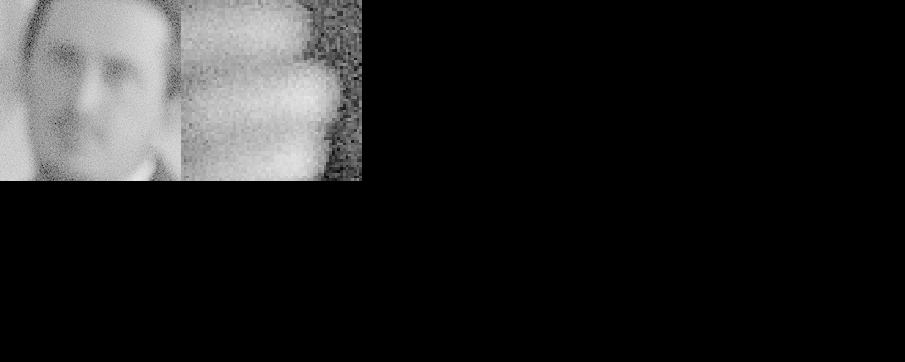

```python
import PIL
for imag in faces_crop:
    print('Results found in file {}:'.format(imag['name']))
    if imag['images2'] == []:
        print('But there ware no faces in that file!')
    else:
        first_imag = imag['images2'][0]
        x=0
        y=0
        contact_sheet=PIL.Image.new(first_imag.mode, (first_imag.width*5,first_imag.height*2))
        for imag2 in imag['images2']:
            contact_sheet.paste(imag2.resize((first_imag.width, first_imag.height)), (x, y) )
    # Now we update our X position. If it is going to be the width of the image, then we set it to 0
    # and update Y as well to point to the next "line" of the contact sheet.
            if x+first_imag.width == contact_sheet.width:
                x=0
                y=y+first_imag.height
            else:
                x=x+first_imag.width
    display(contact_sheet)
```